# Optimal Treatment Analysis

## Outcome Variable

**Outcome Variable:** ever_wasted

## Predictor Variables

**Intervention Variable:** impsan

**Adjustment Set:**

- arm
- sex
- W_mage
- meducyrs
- feducyrs
- hhwealth_quart
- hfoodsec
- W_mhtcm
- W_nrooms
- W_nchldlt5
- W_parity
- impfloor
- safeh20
- delta_W_mage
- delta_meducyrs
- delta_feducyrs
- delta_hhwealth_quart
- delta_hfoodsec
- delta_W_mhtcm
- delta_W_nrooms
- delta_W_nchldlt5
- delta_W_parity
- delta_impfloor
- delta_safeh20

## Stratifying Variables

The analysis was stratified on these variable(s):

- agecat
- studyid
- country

## Data Summary

| agecat | studyid | country | impsan | ever_wasted | n_cell | n |
| --- | --- | --- | --- | --- | --- | --- |
| 0-24 months (no birth wast) | ki0047075b-MAL-ED | BANGLADESH | 1 | 0 | 157 | 242 |
| 0-24 months (no birth wast) | ki0047075b-MAL-ED | BANGLADESH | 1 | 1 | 47 | 242 |
| 0-24 months (no birth wast) | ki0047075b-MAL-ED | BANGLADESH | 0 | 0 | 28 | 242 |
| 0-24 months (no birth wast) | ki0047075b-MAL-ED | BANGLADESH | 0 | 1 | 10 | 242 |
| 0-24 months (no birth wast) | ki0047075b-MAL-ED | BRAZIL | 1 | 0 | 193 | 209 |
| 0-24 months (no birth wast) | ki0047075b-MAL-ED | BRAZIL | 1 | 1 | 12 | 209 |
| 0-24 months (no birth wast) | ki0047075b-MAL-ED | BRAZIL | 0 | 0 | 4 | 209 |
| 0-24 months (no birth wast) | ki0047075b-MAL-ED | BRAZIL | 0 | 1 | 0 | 209 |
| 0-24 months (no birth wast) | ki0047075b-MAL-ED | INDIA | 1 | 0 | 75 | 229 |
| 0-24 months (no birth wast) | ki0047075b-MAL-ED | INDIA | 1 | 1 | 30 | 229 |
| 0-24 months (no birth wast) | ki0047075b-MAL-ED | INDIA | 0 | 0 | 69 | 229 |
| 0-24 months (no birth wast) | ki0047075b-MAL-ED | INDIA | 0 | 1 | 55 | 229 |
| 0-24 months (no birth wast) | ki0047075b-MAL-ED | NEPAL | 1 | 0 | 190 | 236 |
| 0-24 months (no birth wast) | ki0047075b-MAL-ED | NEPAL | 1 | 1 | 45 | 236 |
| 0-24 months (no birth wast) | ki0047075b-MAL-ED | NEPAL | 0 | 0 | 1 | 236 |
| 0-24 months (no birth wast) | ki0047075b-MAL-ED | NEPAL | 0 | 1 | 0 | 236 |
| 0-24 months (no birth wast) | ki0047075b-MAL-ED | PERU | 1 | 0 | 59 | 263 |
| 0-24 months (no birth wast) | ki0047075b-MAL-ED | PERU | 1 | 1 | 6 | 263 |
| 0-24 months (no birth wast) | ki0047075b-MAL-ED | PERU | 0 | 0 | 184 | 263 |
| 0-24 months (no birth wast) | ki0047075b-MAL-ED | PERU | 0 | 1 | 14 | 263 |
| 0-24 months (no birth wast) | ki0047075b-MAL-ED | SOUTH AFRICA | 1 | 0 | 3 | 250 |
| 0-24 months (no birth wast) | ki0047075b-MAL-ED | SOUTH AFRICA | 1 | 1 | 1 | 250 |
| 0-24 months (no birth wast) | ki0047075b-MAL-ED | SOUTH AFRICA | 0 | 0 | 204 | 250 |
| 0-24 months (no birth wast) | ki0047075b-MAL-ED | SOUTH AFRICA | 0 | 1 | 42 | 250 |
| 0-24 months (no birth wast) | ki0047075b-MAL-ED | TANZANIA, UNITED REPUBLIC OF | 1 | 0 | 0 | 241 |
| 0-24 months (no birth wast) | ki0047075b-MAL-ED | TANZANIA, UNITED REPUBLIC OF | 1 | 1 | 0 | 241 |
| 0-24 months (no birth wast) | ki0047075b-MAL-ED | TANZANIA, UNITED REPUBLIC OF | 0 | 0 | 212 | 241 |
| 0-24 months (no birth wast) | ki0047075b-MAL-ED | TANZANIA, UNITED REPUBLIC OF | 0 | 1 | 29 | 241 |
| 0-24 months (no birth wast) | ki1017093-NIH-Birth | BANGLADESH | 1 | 0 | 180 | 598 |
| 0-24 months (no birth wast) | ki1017093-NIH-Birth | BANGLADESH | 1 | 1 | 53 | 598 |

[output cut: 174 more lines]

The following strata were considered:

- agecat: 0-24 months (no birth wast), studyid: ki0047075b-MAL-ED, country: BANGLADESH
- agecat: 0-24 months (no birth wast), studyid: ki0047075b-MAL-ED, country: BRAZIL
- agecat: 0-24 months (no birth wast), studyid: ki0047075b-MAL-ED, country: INDIA
- agecat: 0-24 months (no birth wast), studyid: ki0047075b-MAL-ED, country: NEPAL
- agecat: 0-24 months (no birth wast), studyid: ki0047075b-MAL-ED, country: PERU
- agecat: 0-24 months (no birth wast), studyid: ki0047075b-MAL-ED, country: SOUTH AFRICA
- agecat: 0-24 months (no birth wast), studyid: ki0047075b-MAL-ED, country: TANZANIA, UNITED REPUBLIC OF
- agecat: 0-24 months (no birth wast), studyid: ki1017093-NIH-Birth, country: BANGLADESH
- agecat: 0-24 months (no birth wast), studyid: ki1017093b-PROVIDE, country: BANGLADESH
- agecat: 0-24 months (no birth wast), studyid: ki1017093c-NIH-Crypto, country: BANGLADESH
- agecat: 0-24 months (no birth wast), studyid: ki1114097-CONTENT, country: PERU
- agecat: 0-24 months (no birth wast), studyid: ki1135781-COHORTS, country: GUATEMALA
- agecat: 0-24 months (no birth wast), studyid: ki1135781-COHORTS, country: INDIA
- agecat: 0-24 months (no birth wast), studyid: ki1135781-COHORTS, country: PHILIPPINES
- agecat: 0-24 months (no birth wast), studyid: ki1148112-LCNI-5, country: MALAWI
- agecat: 0-24 months (no birth wast), studyid: kiGH5241-JiVitA-3, country: BANGLADESH
- agecat: 0-24 months (no birth wast), studyid: kiGH5241-JiVitA-4, country: BANGLADESH
- agecat: 0-6 months (no birth wast), studyid: ki0047075b-MAL-ED, country: BANGLADESH
- agecat: 0-6 months (no birth wast), studyid: ki0047075b-MAL-ED, country: BRAZIL
- agecat: 0-6 months (no birth wast), studyid: ki0047075b-MAL-ED, country: INDIA
- agecat: 0-6 months (no birth wast), studyid: ki0047075b-MAL-ED, country: NEPAL
- agecat: 0-6 months (no birth wast), studyid: ki0047075b-MAL-ED, country: PERU
- agecat: 0-6 months (no birth wast), studyid: ki0047075b-MAL-ED, country: SOUTH AFRICA
- agecat: 0-6 months (no birth wast), studyid: ki0047075b-MAL-ED, country: TANZANIA, UNITED REPUBLIC OF
- agecat: 0-6 months (no birth wast), studyid: ki1017093-NIH-Birth, country: BANGLADESH
- agecat: 0-6 months (no birth wast), studyid: ki1017093b-PROVIDE, country: BANGLADESH
- agecat: 0-6 months (no birth wast), studyid: ki1017093c-NIH-Crypto, country: BANGLADESH
- agecat: 0-6 months (no birth wast), studyid: ki1114097-CONTENT, country: PERU
- agecat: 0-6 months (no birth wast), studyid: ki1135781-COHORTS, country: GUATEMALA
- agecat: 0-6 months (no birth wast), studyid: ki1135781-COHORTS, country: INDIA
- agecat: 0-6 months (no birth wast), studyid: ki1135781-COHORTS, country: PHILIPPINES
- agecat: 0-6 months (no birth wast), studyid: ki1148112-LCNI-5, country: MALAWI
- agecat: 0-6 months (no birth wast), studyid: kiGH5241-JiVitA-3, country: BANGLADESH
- agecat: 0-6 months (no birth wast), studyid: kiGH5241-JiVitA-4, country: BANGLADESH
- agecat: 6-24 months, studyid: ki0047075b-MAL-ED, country: BANGLADESH
- agecat: 6-24 months, studyid: ki0047075b-MAL-ED, country: BRAZIL
- agecat: 6-24 months, studyid: ki0047075b-MAL-ED, country: INDIA
- agecat: 6-24 months, studyid: ki0047075b-MAL-ED, country: NEPAL
- agecat: 6-24 months, studyid: ki0047075b-MAL-ED, country: PERU
- agecat: 6-24 months, studyid: ki0047075b-MAL-ED, country: SOUTH AFRICA
- agecat: 6-24 months, studyid: ki0047075b-MAL-ED, country: TANZANIA, UNITED REPUBLIC OF
- agecat: 6-24 months, studyid: ki1017093-NIH-Birth, country: BANGLADESH
- agecat: 6-24 months, studyid: ki1017093b-PROVIDE, country: BANGLADESH
- agecat: 6-24 months, studyid: ki1017093c-NIH-Crypto, country: BANGLADESH
- agecat: 6-24 months, studyid: ki1114097-CONTENT, country: PERU
- agecat: 6-24 months, studyid: ki1135781-COHORTS, country: GUATEMALA
- agecat: 6-24 months, studyid: ki1135781-COHORTS, country: INDIA
- agecat: 6-24 months, studyid: ki1135781-COHORTS, country: PHILIPPINES
- agecat: 6-24 months, studyid: ki1148112-LCNI-5, country: MALAWI
- agecat: 6-24 months, studyid: kiGH5241-JiVitA-3, country: BANGLADESH
- agecat: 6-24 months, studyid: kiGH5241-JiVitA-4, country: BANGLADESH

### Dropped Strata

Some strata were dropped due to rare outcomes:

- agecat: 0-24 months (no birth wast), studyid: ki0047075b-MAL-ED, country: BRAZIL
- agecat: 0-24 months (no birth wast), studyid: ki0047075b-MAL-ED, country: NEPAL
- agecat: 0-24 months (no birth wast), studyid: ki0047075b-MAL-ED, country: SOUTH AFRICA
- agecat: 0-24 months (no birth wast), studyid: ki0047075b-MAL-ED, country: TANZANIA, UNITED REPUBLIC OF
- agecat: 0-24 months (no birth wast), studyid: ki1114097-CONTENT, country: PERU
- agecat: 0-24 months (no birth wast), studyid: ki1135781-COHORTS, country: GUATEMALA
- agecat: 0-24 months (no birth wast), studyid: ki1148112-LCNI-5, country: MALAWI
- agecat: 0-6 months (no birth wast), studyid: ki0047075b-MAL-ED, country: BANGLADESH
- agecat: 0-6 months (no birth wast), studyid: ki0047075b-MAL-ED, country: BRAZIL
- agecat: 0-6 months (no birth wast), studyid: ki0047075b-MAL-ED, country: NEPAL
- agecat: 0-6 months (no birth wast), studyid: ki0047075b-MAL-ED, country: PERU
- agecat: 0-6 months (no birth wast), studyid: ki0047075b-MAL-ED, country: SOUTH AFRICA
- agecat: 0-6 months (no birth wast), studyid: ki0047075b-MAL-ED, country: TANZANIA, UNITED REPUBLIC OF
- agecat: 0-6 months (no birth wast), studyid: ki1017093b-PROVIDE, country: BANGLADESH
- agecat: 0-6 months (no birth wast), studyid: ki1017093c-NIH-Crypto, country: BANGLADESH
- agecat: 0-6 months (no birth wast), studyid: ki1114097-CONTENT, country: PERU
- agecat: 0-6 months (no birth wast), studyid: ki1135781-COHORTS, country: GUATEMALA
- agecat: 0-6 months (no birth wast), studyid: ki1148112-LCNI-5, country: MALAWI
- agecat: 6-24 months, studyid: ki0047075b-MAL-ED, country: BRAZIL
- agecat: 6-24 months, studyid: ki0047075b-MAL-ED, country: NEPAL
- agecat: 6-24 months, studyid: ki0047075b-MAL-ED, country: SOUTH AFRICA
- agecat: 6-24 months, studyid: ki0047075b-MAL-ED, country: TANZANIA, UNITED REPUBLIC OF
- agecat: 6-24 months, studyid: ki1114097-CONTENT, country: PERU
- agecat: 6-24 months, studyid: ki1135781-COHORTS, country: GUATEMALA
- agecat: 6-24 months, studyid: ki1148112-LCNI-5, country: MALAWI

## Methods Detail

We’re interested in the causal parameters $E[Y_a]$ for all values of $a \in \mathcal{A}$. These parameters represent the mean outcome if, possibly contrary to fact, we intervened to set all units to have $A=a$. Under the randomization and positivity assumptions, these are identified by the statistical parameters $\psi_a=E_W[E_{Y|A,W}(Y|A=a,W)]$. In addition, we’re interested in the mean of $Y$, $E[Y]$ under no intervention (the observed mean). We will estimate these parameters by using SuperLearner to fit the relevant likelihood factors – $E_{Y|A,W}(Y|A=a,W)$ and $p(A=a|W)$, and then updating our likelihood fit using a joint TMLE.

For unadjusted analyses ($W=\{\}$), initial likelihoods were estimated using Lrnr_glm to estimate the simple $E(Y|A)$ and Lrnr_mean to estimate $p(A)$. For adjusted analyses, a small library containing Lrnr_glmnet, Lrnr_xgboost, and Lrnr_mean was used.

Having estimated these parameters, we will then use the delta method to estimate relative risks and attributable risks relative to a prespecified baseline level of $A$.

# Results Detail

## Results Plots

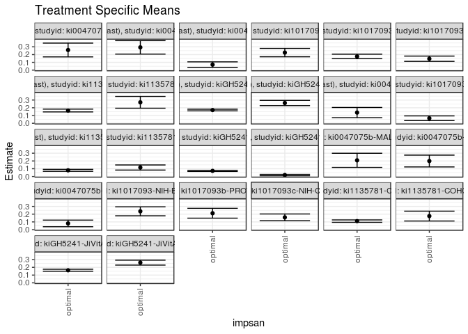

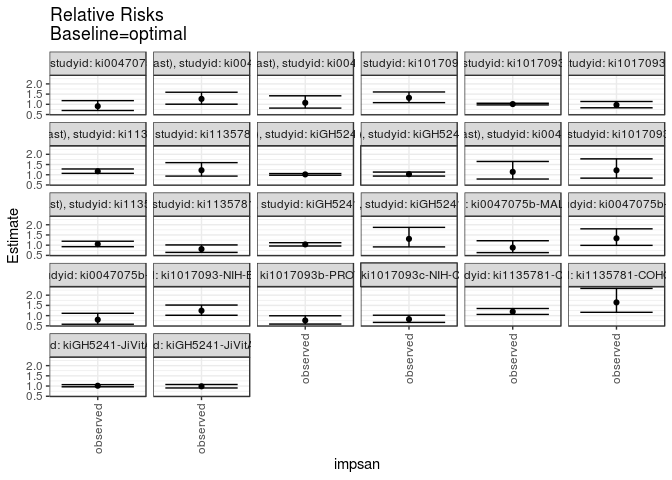

## Results Table

### Parameter: TSM

| agecat | studyid | country | intervention_level | baseline_level | estimate | ci_lower | ci_upper |
| --- | --- | --- | --- | --- | --- | --- | --- |
| 0-24 months (no birth wast) | ki0047075b-MAL-ED | BANGLADESH | optimal | NA | 0.2593917 | 0.1705015 | 0.3482819 |
| 0-24 months (no birth wast) | ki0047075b-MAL-ED | INDIA | optimal | NA | 0.2933717 | 0.2064051 | 0.3803383 |
| 0-24 months (no birth wast) | ki0047075b-MAL-ED | PERU | optimal | NA | 0.0707158 | 0.0348788 | 0.1065528 |
| 0-24 months (no birth wast) | ki1017093-NIH-Birth | BANGLADESH | optimal | NA | 0.2257782 | 0.1717951 | 0.2797613 |
| 0-24 months (no birth wast) | ki1017093b-PROVIDE | BANGLADESH | optimal | NA | 0.1761400 | 0.1468957 | 0.2053843 |
| 0-24 months (no birth wast) | ki1017093c-NIH-Crypto | BANGLADESH | optimal | NA | 0.1468571 | 0.1127662 | 0.1809480 |
| 0-24 months (no birth wast) | ki1135781-COHORTS | INDIA | optimal | NA | 0.1646486 | 0.1467885 | 0.1825088 |
| 0-24 months (no birth wast) | ki1135781-COHORTS | PHILIPPINES | optimal | NA | 0.2705183 | 0.1944174 | 0.3466193 |
| 0-24 months (no birth wast) | kiGH5241-JiVitA-3 | BANGLADESH | optimal | NA | 0.1711129 | 0.1605513 | 0.1816746 |
| 0-24 months (no birth wast) | kiGH5241-JiVitA-4 | BANGLADESH | optimal | NA | 0.2617762 | 0.2279919 | 0.2955605 |
| 0-6 months (no birth wast) | ki0047075b-MAL-ED | INDIA | optimal | NA | 0.1382938 | 0.0727423 | 0.2038453 |
| 0-6 months (no birth wast) | ki1017093-NIH-Birth | BANGLADESH | optimal | NA | 0.0651365 | 0.0347803 | 0.0954927 |
| 0-6 months (no birth wast) | ki1135781-COHORTS | INDIA | optimal | NA | 0.0793724 | 0.0666902 | 0.0920545 |
| 0-6 months (no birth wast) | ki1135781-COHORTS | PHILIPPINES | optimal | NA | 0.1155926 | 0.0826280 | 0.1485573 |
| 0-6 months (no birth wast) | kiGH5241-JiVitA-3 | BANGLADESH | optimal | NA | 0.0725311 | 0.0650308 | 0.0800314 |
| 0-6 months (no birth wast) | kiGH5241-JiVitA-4 | BANGLADESH | optimal | NA | 0.0185824 | 0.0097195 | 0.0274454 |
| 6-24 months | ki0047075b-MAL-ED | BANGLADESH | optimal | NA | 0.2080935 | 0.1170076 | 0.2991794 |
| 6-24 months | ki0047075b-MAL-ED | INDIA | optimal | NA | 0.1991908 | 0.1229629 | 0.2754187 |
| 6-24 months | ki0047075b-MAL-ED | PERU | optimal | NA | 0.0806457 | 0.0379530 | 0.1233385 |
| 6-24 months | ki1017093-NIH-Birth | BANGLADESH | optimal | NA | 0.2366179 | 0.1788082 | 0.2944276 |
| 6-24 months | ki1017093b-PROVIDE | BANGLADESH | optimal | NA | 0.2118400 | 0.1483818 | 0.2752982 |
| 6-24 months | ki1017093c-NIH-Crypto | BANGLADESH | optimal | NA | 0.1585298 | 0.1147124 | 0.2023473 |
| 6-24 months | ki1135781-COHORTS | INDIA | optimal | NA | 0.1102261 | 0.0946552 | 0.1257971 |
| 6-24 months | ki1135781-COHORTS | PHILIPPINES | optimal | NA | 0.1751956 | 0.1113749 | 0.2390162 |
| 6-24 months | kiGH5241-JiVitA-3 | BANGLADESH | optimal | NA | 0.1623974 | 0.1494050 | 0.1753898 |
| 6-24 months | kiGH5241-JiVitA-4 | BANGLADESH | optimal | NA | 0.2608170 | 0.2289380 | 0.2926960 |

### Parameter: E(Y)

| agecat | studyid | country | intervention_level | baseline_level | estimate | ci_lower | ci_upper |
| --- | --- | --- | --- | --- | --- | --- | --- |
| 0-24 months (no birth wast) | ki0047075b-MAL-ED | BANGLADESH | observed | NA | 0.2355372 | 0.1819640 | 0.2891104 |
| 0-24 months (no birth wast) | ki0047075b-MAL-ED | INDIA | observed | NA | 0.3711790 | 0.3084692 | 0.4338889 |
| 0-24 months (no birth wast) | ki0047075b-MAL-ED | PERU | observed | NA | 0.0760456 | 0.0439490 | 0.1081423 |
| 0-24 months (no birth wast) | ki1017093-NIH-Birth | BANGLADESH | observed | NA | 0.2976589 | 0.2609818 | 0.3343359 |
| 0-24 months (no birth wast) | ki1017093b-PROVIDE | BANGLADESH | observed | NA | 0.1781022 | 0.1494298 | 0.2067746 |
| 0-24 months (no birth wast) | ki1017093c-NIH-Crypto | BANGLADESH | observed | NA | 0.1426649 | 0.1175009 | 0.1678289 |
| 0-24 months (no birth wast) | ki1135781-COHORTS | INDIA | observed | NA | 0.1925912 | 0.1818265 | 0.2033558 |
| 0-24 months (no birth wast) | ki1135781-COHORTS | PHILIPPINES | observed | NA | 0.3301642 | 0.3030549 | 0.3572735 |
| 0-24 months (no birth wast) | kiGH5241-JiVitA-3 | BANGLADESH | observed | NA | 0.1739632 | 0.1661367 | 0.1817897 |
| 0-24 months (no birth wast) | kiGH5241-JiVitA-4 | BANGLADESH | observed | NA | 0.2693935 | 0.2426940 | 0.2960930 |
| 0-6 months (no birth wast) | ki0047075b-MAL-ED | INDIA | observed | NA | 0.1578947 | 0.1104594 | 0.2053301 |
| 0-6 months (no birth wast) | ki1017093-NIH-Birth | BANGLADESH | observed | NA | 0.0793103 | 0.0572998 | 0.1013209 |
| 0-6 months (no birth wast) | ki1135781-COHORTS | INDIA | observed | NA | 0.0835141 | 0.0755270 | 0.0915012 |
| 0-6 months (no birth wast) | ki1135781-COHORTS | PHILIPPINES | observed | NA | 0.0935315 | 0.0766512 | 0.1104118 |
| 0-6 months (no birth wast) | kiGH5241-JiVitA-3 | BANGLADESH | observed | NA | 0.0752554 | 0.0699632 | 0.0805476 |
| 0-6 months (no birth wast) | kiGH5241-JiVitA-4 | BANGLADESH | observed | NA | 0.0243328 | 0.0149179 | 0.0337477 |
| 6-24 months | ki0047075b-MAL-ED | BANGLADESH | observed | NA | 0.1833333 | 0.1342773 | 0.2323893 |
| 6-24 months | ki0047075b-MAL-ED | INDIA | observed | NA | 0.2660944 | 0.2092298 | 0.3229590 |
| 6-24 months | ki0047075b-MAL-ED | PERU | observed | NA | 0.0646388 | 0.0348650 | 0.0944125 |
| 6-24 months | ki1017093-NIH-Birth | BANGLADESH | observed | NA | 0.2939002 | 0.2554778 | 0.3323226 |
| 6-24 months | ki1017093b-PROVIDE | BANGLADESH | observed | NA | 0.1615008 | 0.1323459 | 0.1906557 |
| 6-24 months | ki1017093c-NIH-Crypto | BANGLADESH | observed | NA | 0.1307371 | 0.1060790 | 0.1553953 |
| 6-24 months | ki1135781-COHORTS | INDIA | observed | NA | 0.1315423 | 0.1221962 | 0.1408884 |
| 6-24 months | ki1135781-COHORTS | PHILIPPINES | observed | NA | 0.2884097 | 0.2617831 | 0.3150363 |
| 6-24 months | kiGH5241-JiVitA-3 | BANGLADESH | observed | NA | 0.1648339 | 0.1556475 | 0.1740202 |
| 6-24 months | kiGH5241-JiVitA-4 | BANGLADESH | observed | NA | 0.2573427 | 0.2311603 | 0.2835250 |

### Parameter: RR

| agecat | studyid | country | intervention_level | baseline_level | estimate | ci_lower | ci_upper |
| --- | --- | --- | --- | --- | --- | --- | --- |
| 0-24 months (no birth wast) | ki0047075b-MAL-ED | BANGLADESH | observed | optimal | 0.9080368 | 0.6985361 | 1.1803695 |
| 0-24 months (no birth wast) | ki0047075b-MAL-ED | INDIA | observed | optimal | 1.2652175 | 1.0054531 | 1.5920935 |
| 0-24 months (no birth wast) | ki0047075b-MAL-ED | PERU | observed | optimal | 1.0753702 | 0.8160893 | 1.4170275 |
| 0-24 months (no birth wast) | ki1017093-NIH-Birth | BANGLADESH | observed | optimal | 1.3183686 | 1.0834626 | 1.6042047 |
| 0-24 months (no birth wast) | ki1017093b-PROVIDE | BANGLADESH | observed | optimal | 1.0111398 | 0.9724746 | 1.0513424 |
| 0-24 months (no birth wast) | ki1017093c-NIH-Crypto | BANGLADESH | observed | optimal | 0.9714538 | 0.8292616 | 1.1380274 |
| 0-24 months (no birth wast) | ki1135781-COHORTS | INDIA | observed | optimal | 1.1697101 | 1.0669015 | 1.2824255 |
| 0-24 months (no birth wast) | ki1135781-COHORTS | PHILIPPINES | observed | optimal | 1.2204874 | 0.9347996 | 1.5934854 |
| 0-24 months (no birth wast) | kiGH5241-JiVitA-3 | BANGLADESH | observed | optimal | 1.0166574 | 0.9762628 | 1.0587235 |
| 0-24 months (no birth wast) | kiGH5241-JiVitA-4 | BANGLADESH | observed | optimal | 1.0290985 | 0.9360417 | 1.1314065 |
| 0-6 months (no birth wast) | ki0047075b-MAL-ED | INDIA | observed | optimal | 1.1417339 | 0.7899909 | 1.6500902 |
| 0-6 months (no birth wast) | ki1017093-NIH-Birth | BANGLADESH | observed | optimal | 1.2176021 | 0.8341548 | 1.7773139 |
| 0-6 months (no birth wast) | ki1135781-COHORTS | INDIA | observed | optimal | 1.0521812 | 0.9272835 | 1.1939017 |
| 0-6 months (no birth wast) | ki1135781-COHORTS | PHILIPPINES | observed | optimal | 0.8091473 | 0.6468699 | 1.0121345 |
| 0-6 months (no birth wast) | kiGH5241-JiVitA-3 | BANGLADESH | observed | optimal | 1.0375605 | 0.9600324 | 1.1213494 |
| 0-6 months (no birth wast) | kiGH5241-JiVitA-4 | BANGLADESH | observed | optimal | 1.3094517 | 0.9164143 | 1.8710574 |
| 6-24 months | ki0047075b-MAL-ED | BANGLADESH | observed | optimal | 0.8810142 | 0.6373569 | 1.2178200 |
| 6-24 months | ki0047075b-MAL-ED | INDIA | observed | optimal | 1.3358773 | 0.9912293 | 1.8003587 |
| 6-24 months | ki0047075b-MAL-ED | PERU | observed | optimal | 0.8015152 | 0.5774933 | 1.1124400 |
| 6-24 months | ki1017093-NIH-Birth | BANGLADESH | observed | optimal | 1.2420878 | 1.0172450 | 1.5166278 |
| 6-24 months | ki1017093b-PROVIDE | BANGLADESH | observed | optimal | 0.7623717 | 0.5859386 | 0.9919308 |
| 6-24 months | ki1017093c-NIH-Crypto | BANGLADESH | observed | optimal | 0.8246847 | 0.6672178 | 1.0193147 |
| 6-24 months | ki1135781-COHORTS | INDIA | observed | optimal | 1.1933857 | 1.0567004 | 1.3477514 |
| 6-24 months | ki1135781-COHORTS | PHILIPPINES | observed | optimal | 1.6462157 | 1.1619418 | 2.3323253 |
| 6-24 months | kiGH5241-JiVitA-3 | BANGLADESH | observed | optimal | 1.0150032 | 0.9629279 | 1.0698946 |
| 6-24 months | kiGH5241-JiVitA-4 | BANGLADESH | observed | optimal | 0.9866791 | 0.9051158 | 1.0755923 |

### Parameter: PAR

| agecat | studyid | country | intervention_level | baseline_level | estimate | ci_lower | ci_upper |
| --- | --- | --- | --- | --- | --- | --- | --- |
| 0-24 months (no birth wast) | ki0047075b-MAL-ED | BANGLADESH | optimal | NA | -0.0238545 | -0.0919678 | 0.0442588 |
| 0-24 months (no birth wast) | ki0047075b-MAL-ED | INDIA | optimal | NA | 0.0778073 | 0.0102115 | 0.1454031 |
| 0-24 months (no birth wast) | ki0047075b-MAL-ED | PERU | optimal | NA | 0.0053299 | -0.0142851 | 0.0249448 |
| 0-24 months (no birth wast) | ki1017093-NIH-Birth | BANGLADESH | optimal | NA | 0.0718807 | 0.0273279 | 0.1164335 |
| 0-24 months (no birth wast) | ki1017093b-PROVIDE | BANGLADESH | optimal | NA | 0.0019622 | -0.0049095 | 0.0088338 |
| 0-24 months (no birth wast) | ki1017093c-NIH-Crypto | BANGLADESH | optimal | NA | -0.0041922 | -0.0274152 | 0.0190308 |
| 0-24 months (no birth wast) | ki1135781-COHORTS | INDIA | optimal | NA | 0.0279425 | 0.0127421 | 0.0431430 |
| 0-24 months (no birth wast) | ki1135781-COHORTS | PHILIPPINES | optimal | NA | 0.0596459 | -0.0125171 | 0.1318088 |
| 0-24 months (no birth wast) | kiGH5241-JiVitA-3 | BANGLADESH | optimal | NA | 0.0028503 | -0.0040834 | 0.0097841 |
| 0-24 months (no birth wast) | kiGH5241-JiVitA-4 | BANGLADESH | optimal | NA | 0.0076173 | -0.0172911 | 0.0325257 |
| 0-6 months (no birth wast) | ki0047075b-MAL-ED | INDIA | optimal | NA | 0.0196009 | -0.0317014 | 0.0709032 |
| 0-6 months (no birth wast) | ki1017093-NIH-Birth | BANGLADESH | optimal | NA | 0.0141738 | -0.0108273 | 0.0391750 |
| 0-6 months (no birth wast) | ki1135781-COHORTS | INDIA | optimal | NA | 0.0041417 | -0.0058889 | 0.0141723 |
| 0-6 months (no birth wast) | ki1135781-COHORTS | PHILIPPINES | optimal | NA | -0.0220612 | -0.0481738 | 0.0040514 |
| 0-6 months (no birth wast) | kiGH5241-JiVitA-3 | BANGLADESH | optimal | NA | 0.0027243 | -0.0029167 | 0.0083653 |
| 0-6 months (no birth wast) | kiGH5241-JiVitA-4 | BANGLADESH | optimal | NA | 0.0057504 | -0.0016140 | 0.0131147 |
| 6-24 months | ki0047075b-MAL-ED | BANGLADESH | optimal | NA | -0.0247602 | -0.0930297 | 0.0435094 |
| 6-24 months | ki0047075b-MAL-ED | INDIA | optimal | NA | 0.0669037 | 0.0070636 | 0.1267437 |
| 6-24 months | ki0047075b-MAL-ED | PERU | optimal | NA | -0.0160070 | -0.0425099 | 0.0104960 |
| 6-24 months | ki1017093-NIH-Birth | BANGLADESH | optimal | NA | 0.0572823 | 0.0098281 | 0.1047366 |
| 6-24 months | ki1017093b-PROVIDE | BANGLADESH | optimal | NA | -0.0503392 | -0.1056777 | 0.0049993 |
| 6-24 months | ki1017093c-NIH-Crypto | BANGLADESH | optimal | NA | -0.0277927 | -0.0615244 | 0.0059390 |
| 6-24 months | ki1135781-COHORTS | INDIA | optimal | NA | 0.0213162 | 0.0078322 | 0.0348001 |
| 6-24 months | ki1135781-COHORTS | PHILIPPINES | optimal | NA | 0.1132141 | 0.0517407 | 0.1746875 |
| 6-24 months | kiGH5241-JiVitA-3 | BANGLADESH | optimal | NA | 0.0024365 | -0.0061058 | 0.0109787 |
| 6-24 months | kiGH5241-JiVitA-4 | BANGLADESH | optimal | NA | -0.0034743 | -0.0259233 | 0.0189747 |

### Parameter: PAF

| agecat | studyid | country | intervention_level | baseline_level | estimate | ci_lower | ci_upper |
| --- | --- | --- | --- | --- | --- | --- | --- |
| 0-24 months (no birth wast) | ki0047075b-MAL-ED | BANGLADESH | optimal | NA | -0.1012770 | -0.4315651 | 0.1528077 |
| 0-24 months (no birth wast) | ki0047075b-MAL-ED | INDIA | optimal | NA | 0.2096221 | 0.0054236 | 0.3718962 |
| 0-24 months (no birth wast) | ki0047075b-MAL-ED | PERU | optimal | NA | 0.0700877 | -0.2253561 | 0.2942974 |
| 0-24 months (no birth wast) | ki1017093-NIH-Birth | BANGLADESH | optimal | NA | 0.2414868 | 0.0770332 | 0.3766382 |
| 0-24 months (no birth wast) | ki1017093b-PROVIDE | BANGLADESH | optimal | NA | 0.0110171 | -0.0283045 | 0.0488351 |
| 0-24 months (no birth wast) | ki1017093c-NIH-Crypto | BANGLADESH | optimal | NA | -0.0293851 | -0.2058920 | 0.1212865 |
| 0-24 months (no birth wast) | ki1135781-COHORTS | INDIA | optimal | NA | 0.1450873 | 0.0627064 | 0.2202276 |
| 0-24 months (no birth wast) | ki1135781-COHORTS | PHILIPPINES | optimal | NA | 0.1806552 | -0.0697480 | 0.3724448 |
| 0-24 months (no birth wast) | kiGH5241-JiVitA-3 | BANGLADESH | optimal | NA | 0.0163845 | -0.0243144 | 0.0554663 |
| 0-24 months (no birth wast) | kiGH5241-JiVitA-4 | BANGLADESH | optimal | NA | 0.0282757 | -0.0683284 | 0.1161444 |
| 0-6 months (no birth wast) | ki0047075b-MAL-ED | INDIA | optimal | NA | 0.1241392 | -0.2658373 | 0.3939725 |
| 0-6 months (no birth wast) | ki1017093-NIH-Birth | BANGLADESH | optimal | NA | 0.1787137 | -0.1988182 | 0.4373532 |
| 0-6 months (no birth wast) | ki1135781-COHORTS | INDIA | optimal | NA | 0.0495934 | -0.0784189 | 0.1624101 |
| 0-6 months (no birth wast) | ki1135781-COHORTS | PHILIPPINES | optimal | NA | -0.2358689 | -0.5459059 | 0.0119890 |
| 0-6 months (no birth wast) | kiGH5241-JiVitA-3 | BANGLADESH | optimal | NA | 0.0362007 | -0.0416315 | 0.1082173 |
| 0-6 months (no birth wast) | kiGH5241-JiVitA-4 | BANGLADESH | optimal | NA | 0.2363216 | -0.0912095 | 0.4655429 |
| 6-24 months | ki0047075b-MAL-ED | BANGLADESH | optimal | NA | -0.1350555 | -0.5689796 | 0.1788606 |
| 6-24 months | ki0047075b-MAL-ED | INDIA | optimal | NA | 0.2514283 | -0.0088483 | 0.4445551 |
| 6-24 months | ki0047075b-MAL-ED | PERU | optimal | NA | -0.2476370 | -0.7316218 | 0.1010751 |
| 6-24 months | ki1017093-NIH-Birth | BANGLADESH | optimal | NA | 0.1949039 | 0.0169527 | 0.3406425 |
| 6-24 months | ki1017093b-PROVIDE | BANGLADESH | optimal | NA | -0.3116962 | -0.7066634 | -0.0081348 |
| 6-24 months | ki1017093c-NIH-Crypto | BANGLADESH | optimal | NA | -0.2125846 | -0.4987610 | 0.0189487 |
| 6-24 months | ki1135781-COHORTS | INDIA | optimal | NA | 0.1620479 | 0.0536579 | 0.2580234 |
| 6-24 months | ki1135781-COHORTS | PHILIPPINES | optimal | NA | 0.3925462 | 0.1393717 | 0.5712433 |
| 6-24 months | kiGH5241-JiVitA-3 | BANGLADESH | optimal | NA | 0.0147814 | -0.0384993 | 0.0653285 |
| 6-24 months | kiGH5241-JiVitA-4 | BANGLADESH | optimal | NA | -0.0135008 | -0.1048310 | 0.0702797 |